# Nanofish: GSH content

# Set up environment

## Load libraries

## Load functions

## Load data

### Adjust classes and transformations

```
'data.frame':   467 obs. of  30 variables:
 $ StudyID             : Factor w/ 59 levels "2","3","4","5",..: 40 40 50 50 50 50 16 16 16 7 ...
 $ StudyCluster        : Factor w/ 34 levels "1","2","3","5",..: 4 4 5 5 5 5 4 4 4 18 ...
 $ Study               : Factor w/ 59 levels "Ašmonaitė et al., 2020",..: 1 1 2 2 2 2 3 3 3 4 ...
 $ Year                : int  2020 2020 2018 2018 2018 2018 2020 2020 2020 2019 ...
 $ EScluster           : Factor w/ 101 levels "1","2","3","4",..: 1 1 2 2 2 2 3 3 3 4 ...
 $ AdministrationRoute : Factor w/ 6 levels "Food","Injection",..: 1 1 4 4 4 4 1 1 1 4 ...
 $ Concentration_mg_L  : num  NA NA 0.26 0.69 0.26 0.69 NA NA NA 20 ...
 $ ParticleMaterial    : Factor w/ 7 levels "Aminoplast","LDPE",..: 6 3 1 1 1 1 3 3 3 6 ...
 $ Species             : Factor w/ 20 levels "Argyrosomus regius",..: 9 9 8 8 8 8 9 9 9 7 ...
 $ ParticleShape       : Factor w/ 4 levels "Irregular","Sphere",..: 2 2 2 2 2 2 2 2 2 2 ...
 $ Sex                 : Factor w/ 5 levels "F","F:M","FM",..: 5 5 5 5 5 5 5 5 5 NA ...
 $ DevelopmentalStage  : Factor w/ 5 levels "Embrio","Larva",..: 4 4 4 4 4 4 4 4 4 2 ...
 $ ExposureDurationCat : Factor w/ 3 levels "15 days +","5-15 days",..: 2 2 3 3 3 3 1 1 1 3 ...
 $ ExposureDurationDays: int  14 14 4 4 4 4 28 28 28 2 ...
```

[output cut: 16 more lines]

### Calculate Effect Size

```r
df_original <- metafor::escalc(measure = "SMD", n1i = n_treat, n2i = n_ctrl, m1i = mean_treat,
    m2i = mean_ctrl, sd1i = STD_treat, sd2i = STD_ctrl, data = df_original, vtype = "UB")
# write.csv(df_original,file = 'mvMetaAnalysis_SMDs.csv')
```

### Create variables

```r
outcome <- as.character(outcomeslist[[n_outcome]])

mRF <- list()  # random effects formula investigation models
mRE <- list()  # random effects multilevel models
mMR <- list()  # multilevel metaregression models

colormap <- c(Embrio = "khaki", Larva = "lightgreen", Juvenile = "lightskyblue",
    Adult = "salmon", Unclear = "plum", ExposureDurationDays = "cornflowerblue",
    ParticleSizeMean = "chartreuse4", Concentration_mg_L = "#fa0079ff", Aminoplast = "chocolate4",
    LDPE = "#2200faff", PE = "#0089faff", PET = "#00faedff", PLA = "#00fa29ff", PS = "#faf200ff",
    PVC = "#fa9a00ff", `Publication year` = "black", Variance = "navyblue")
```

### Select outcome

```
[1] "GSH content"
```

|  | StudyID | StudyCluster | Study | Year | EScluster | AdministrationRoute | Concentration_mg_L | ParticleMaterial | Species | ParticleShape | Sex | DevelopmentalStage | ExposureDurationCat | ExposureDurationDays | ParticleSizeRange | ParticleSizeMean | ParticleSizeCat | Outcome | OutcomeCategory | Test_or_Assay | OutcomeVariable | Group | n_of_groups | n_ctrl | mean_ctrl | STD_ctrl | n_treat | mean_treat | STD_treat | … |
| --- | --- | --- | --- | --- | --- | --- | --- | --- | --- | --- | --- | --- | --- | --- | --- | --- | --- | --- | --- | --- | --- | --- | --- | --- | --- | --- | --- | --- | --- | --- |
| 37 | 28 | 1 | Chagas et al., 2021 | 2021 | 9 | Water: Semi-static system | 2.5 | PLA | Danio rerio | Irregular | FM | Adult | 15 days + | 30 | 2.34 | 2.34 | micro | GSH content | Neurochemical outcomes | Oxidative Stress | GSH content | BP I (2,5 mg/L) | 2 | 10 | 392.788 | 42.857 | 10 | 435.645 | 65.326 | … |
| 38 | 28 | 1 | Chagas et al., 2021 | 2021 | 9 | Water: Semi-static system | 5 | PLA | Danio rerio | Irregular | FM | Adult | 15 days + | 30 | 2.34 | 2.34 | micro | GSH content | Neurochemical outcomes | Oxidative Stress | GSH content | BP II (5 mg/L) | 2 | 10 | 392.788 | 42.857 | 10 | 386.13 | 23.717 | … |
| 45 | 76 | 11 | Chen et al., 2017 | 2017 | 10 | Water: Semi-static system | 1 | PS | Danio rerio | Sphere |  | Larva | 5-15 days | 5 | 45 | 45 | micro | GSH content | Neurochemical outcomes | Oxidative Stress | GSH content | MPP | 2 | 3 | 0.096 | 0.003 | 3 | 0.084 | 0.004 | … |
| 46 | 76 | 11 | Chen et al., 2017 | 2017 | 10 | Water: Semi-static system | 1 | PS | Danio rerio | Sphere |  | Larva | 5-15 days | 5 | 0.05 | 0.05 | nano | GSH content | Neurochemical outcomes | Oxidative Stress | GSH content | NPP | 2 | 3 | 0.096 | 0.003 | 3 | 0.069 | 0.002 | … |
| 103 | 59 | 1 | Estrela et al., 2021 | 2021 | 38 | Water: Static system | 0.76 | PS | Ctenopharyngodon idella | Sphere | F:M | Juvenile | up to 96h | 3 | 0.02-0.026 | 0.023 | nano | GSH content | Neurochemical outcomes | Oxidative Stress | GSH content | PS NP | 1 | 16 | 0.302 | 0.131 | 16 | 0.746 | 0.034 | … |
| 241 | 62 | 25 | Santos et al., 2020 | 2020 | 73 | Water: Semi-static system | 2 | Aminoplast | Danio rerio | Sphere |  | Larva | up to 96h | 4 | 1-5 | 3 | micro | GSH content | Neurochemical outcomes | Oxidative Stress | GSH content | MP | 1 | 5 | 1815 | 192.7 | 5 | 188 | 183.7 | … |
| 268 | 112 | 25 | Santos et al., 2021b | 2021 | 75 | Water: Semi-static system | 2 | Aminoplast | Danio rerio | Sphere |  | Larva | up to 96h | 2 | 1-5 | 3 | micro | GSH content | Neurochemical outcomes | Oxidative Stress | GSH content | MPs 2 | 1 | 3 | 5.6 | 1 | 3 | 6.5 | 1.1 | … |
| 269 | 112 | 25 | Santos et al., 2021b | 2021 | 76 | Water: Semi-static system | 2 | Aminoplast | Danio rerio | Sphere |  | Larva | 5-15 days | 6 | 1-5 | 3 | micro | GSH content | Neurochemical outcomes | Oxidative Stress | GSH content | MPs 6 | 1 | 3 | 11.8 | 1.7 | 3 | 13.8 | 1.1 | … |
| 270 | 112 | 25 | Santos et al., 2021b | 2021 | 77 | Water: Semi-static system | 2 | Aminoplast | Danio rerio | Sphere |  | Larva | 5-15 days | 10 | 1-5 | 3 | micro | GSH content | Neurochemical outcomes | Oxidative Stress | GSH content | MPs 10 | 1 | 3 | 19.1 | 2.8 | 3 | 15.8 | 3.7 | … |
| 271 | 112 | 25 | Santos et al., 2021b | 2021 | 78 | Water: Semi-static system | 2 | Aminoplast | Danio rerio | Sphere |  | Larva | 5-15 days | 14 | 1-5 | 3 | micro | GSH content | Neurochemical outcomes | Oxidative Stress | GSH content | MPs 14 | 1 | 3 | 8.5 | 0.6 | 3 | 15.3 | 3 | … |

[output cut: 4 more lines]

# Exploratory data analysis

## Funnel plot

> Before running any meta-analytic model, it is important to explore the meta-analytic dataset to search for potential outliers that could represent data extraction errors. (Nakagawa et al. 2022)

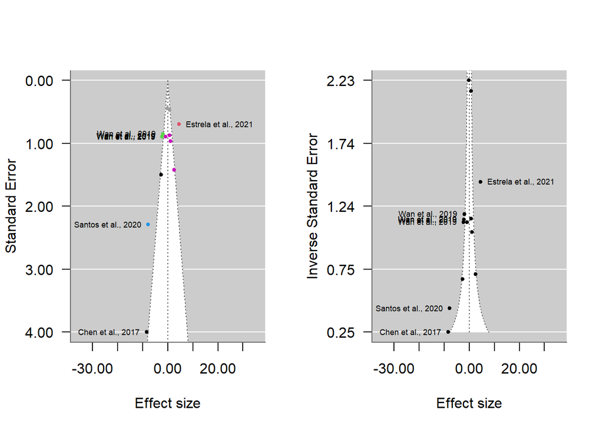

## Alluvial plot

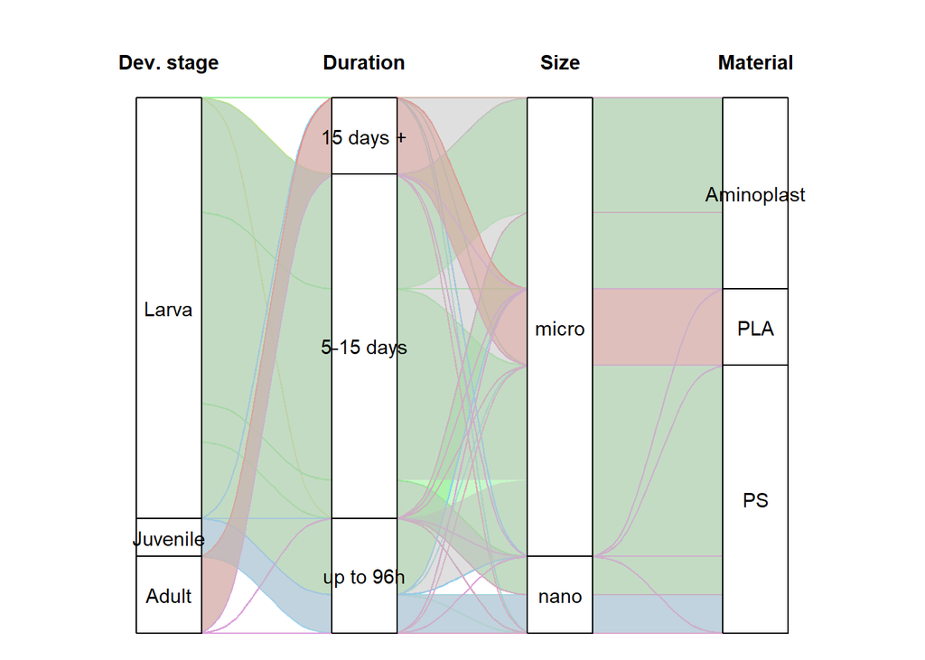

# Multilevel meta-analytic model

## Random effects formula desing

```
[1] "Considering number of studies: 6, number of ES clusters: 9 and number of independent observations of ES: 14, the random effects formula for GSH content is: ~1 | Study/EScluster/ESid"
```

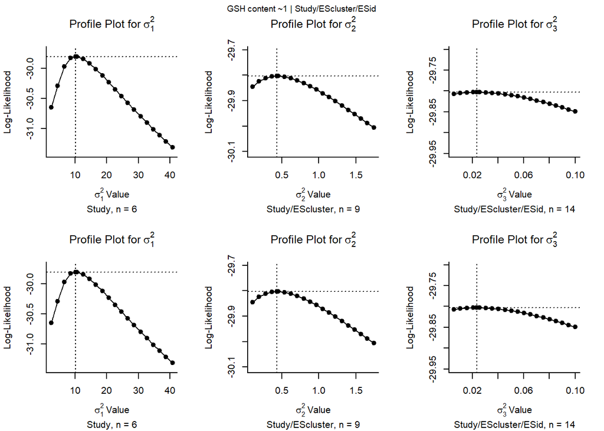

> A profile likelihood plot should show a single peak at the corresponding ML/REML estimate. If `refline=TRUE` (the default), the value of the parameter estimate is indicated by a dotted vertical line and its log-likelihood value by a dotted horizontal line. Hence, the intersection of these two lines should correspond to the peak (assuming that the model was fitted with ML/REML estimation).

> When profiling a variance component (or some other parameter that cannot be negative), the peak may be at zero (if this corresponds to the ML/REML estimate of the parameter). In this case, the profiled log-likelihood should be a monotonically decreasing function of the parameter. Similarly, when profiling a correlation component, the peak may be at -1 or +1.

> If the profiled log-likelihood has multiple peaks, this indicates that the likelihood surface is not unimodal. In such cases, the ML/REML estimate may correspond to a local optimum (when the intersection of the two dotted lines is not at the highest peak).

> If the profile is flat (over the entire parameter space or large portions of it), then this suggests that at least some of the parameters of the model are not identifiable (and the parameter estimates obtained are to some extent arbitrary). See Raue et al. (2009) for some further discussion of parameter identifiability and the use of profile likelihoods to check for this.

> The function checks whether any profiled log-likelihood value is actually larger than the log-likelihood of the fitted model (using a numerical tolerance of `lltol`). If so, a warning is issued as this might indicate that the optimizer did not identify the actual ML/REML estimate of the parameter profiled.[Viechtbauer (2022)](Viechtbauer 2010)

## Additional random effects factors

Study cluster, particle material and species as random effects term can further improve results?

|  | Nested | +StudyCluster | +Particle Material | +Species |
| --- | --- | --- | --- | --- |
| logLik: | -29.80304892933574 | -29.80304893239319 | -29.80304952894682 | -29.75768693611408 |
| deviance: | 33.39606680301519 | 33.39606680913008 | 33.39606800223734 | 33.30534281657187 |
| AIC: | 67.60609785867149 | 69.60609786478636 | 69.60609905789363 | 69.51537387222815 |
| BIC: | 70.16232717713251 | 72.80138451286267 | 72.80138570596993 | 72.71066052030444 |
| AICc: | 72.05054230311593 | 77.10609786478636 | 77.10609905789363 | 77.01537387222815 |

|  | Comparison | LRT | p_value |
| --- | --- | --- | --- |
| 1 | +Study Cluster | 0 | 1 |
| 2 | +Particle Material | 0 | 1 |
| 3 | +Species | 0.09 | 0.763 |

Additional term to insert: none

## Main result: Multilevel model with $\rho = 0.5$ and robust variance estimate

```r
# Assumed correlation of rho = 0.5, except if there is only one ES by Study (no
# correlation)
if (nES == nSt) {
    VCVrho <- 0
    VCV <- df$vi
} else {
    VCVrho <- 0.5
    VCV <- vcalc(vi, cluster = interaction(df$EScluster, df$Study), obs = ESid, data = df,
        rho = VCVrho)
}

mname1 <- "ML"
mname2 <- paste0(mname1, "_RobVar")

mRE[[mname1]] <- rma.mv(yi, VCV, random = RE_formula, data = df, slab = Study, method = "REML",
    test = "t", dfs = "contain", level = 95)
mRE[[mname1]] <- additional_results(mRE[[mname1]])

mRE[[mname2]] <- robust(mRE[[mname1]], cluster = df$Study, clubSandwich = TRUE)

mRE[[mname2]] <- additional_results(mRE[[mname2]])

I2_ML_RobVar <- i2_ml(mRE[[mname2]])
# I2_ML_RobVar <- i2_ml(mRE[[mname2]], boot = 1000)

extract_report(mRE[[mname2]], outcome, RE_formula)
```

#### Diagnostics plots and results

```
Multivariate Meta-Analysis Model (k = 14; method: REML)

  logLik  Deviance       AIC       BIC      AICc
-26.6185   53.2370   61.2370   63.4968   66.2370

Variance Components:

             estim    sqrt  nlvls  fixed                factor
sigma^2.1  12.1428  3.4847      6     no                 Study
sigma^2.2   0.3587  0.5989      9     no       Study/EScluster
sigma^2.3   0.0931  0.3051     14     no  Study/EScluster/ESid

Test for Heterogeneity:
Q(df = 13) = 76.3473, p-val < .0001

Number of estimates:   14
Number of clusters:    6
Estimates per cluster: 0-4 (mean: 0.24, median: 0)

Model Results:

estimate      se¹     tval¹    df¹    pval¹    ci.lb¹   ci.ub¹
 -0.7975  1.5098   -0.5282   4.92   0.6203   -4.6969   3.1018

---
Signif. codes:  0 '***' 0.001 '**' 0.01 '*' 0.05 '.' 0.1 ' ' 1

1) results based on cluster-robust inference (var-cov estimator: CR2,
   approx t-test and confidence interval, df: Satterthwaite approx)
```

```
               I2_Total                I2_Study      I2_Study/EScluster
             94.7963950              91.3956324               2.7000177
I2_Study/EScluster/ESid
              0.7007448
```

```
$results
        % of total variance   I2
Level 1           5.2036050  ---
Level 2           0.7007448  0.7
Level 3           2.7000177  2.7
Level 4          91.3956324 91.4

$totalI2
[1] 94.79639

$plot
```

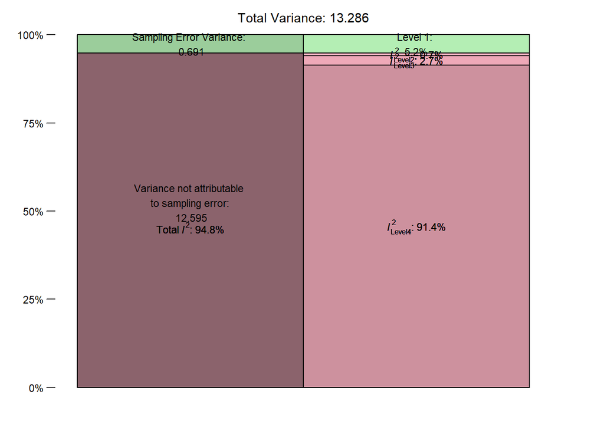

```
attr(,"class")
[1] "mlm.variance.distribution" "list"
```

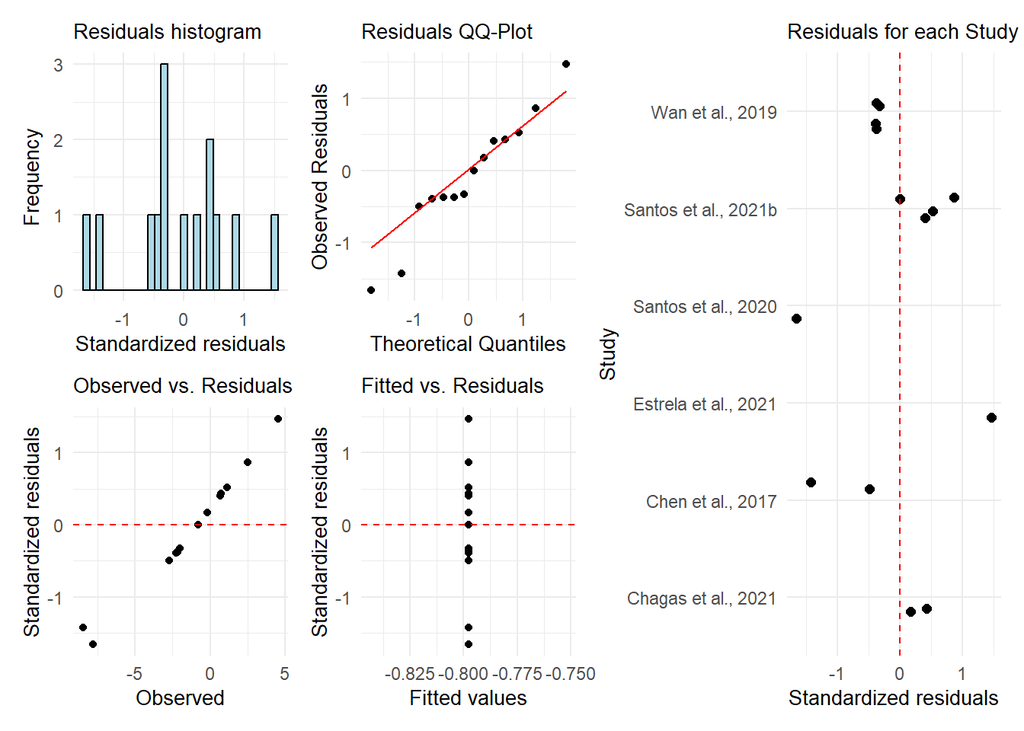

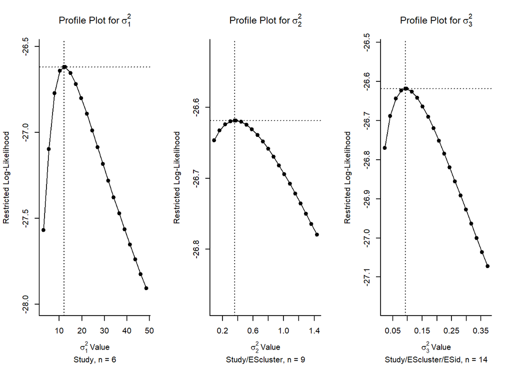

The meta-analysis comprised 14 comparisons from 9 control group clusters of 6 independent studies, so the random formula for GSH content was ~1 | Study/EScluster/ESid.

No difference between treatment and control groups (ES = -0.7975287 ± 1.5098016, CI95% = -4.696898 to 3.1018406, predicted interval -10.7582403 to 9.1631829), with high heterogeneity (i² = 94.8, Q = 76.3473333, p < 0.001 ) and variance explained by each component of $\sigma^2_{Study} = 12.14$, $\sigma^2_{EScluster} = 0.36$, $\sigma^2_{ESid} = 0.09$.

# Publication bias

> **Small-study effect:** when small studies (with small sample sizes) tend to report large effect sizes. (Yang et al. 2023)

> While the PET method works best when the true effect captured by β0β0 is **zero**, PEESE shows a better performance when the true effect is **not** zero. Stanley and Doucouliagos ([2014](https://bookdown.org/MathiasHarrer/Doing_Meta_Analysis_in_R/references.html#ref-stanley2014meta)) therefore proposed to combine both methods, in order to balance out their individual strengths. The resulting approach is the PET-PEESE method. PET-PEESE uses the intercept β0 of either PET or PEESE as the estimate of the corrected true effect.

> Whether PET or PEESE is used depends on the size of the intercept calculated by the PET method. When β0PET is significantly larger than zero in a one-sided test with α = 0.05, we use the intercept of PEESE as the true effect size estimate. If PET’s intercept is not significantly larger than zero, we remain with the PET estimate.

> In most implementations of regression models in *R*, it is conventional to test the significance of coefficients using a two-sided test (i.e. we test if a ββ weight significantly differs from zero, no matter the direction). To assume a one-sided test with α = 0.05, we already regard the intercept as significant when p < 0.1, and when the estimate of β0 is larger than zero<sup>38</sup>. (Harrer et al., n.d.)

> **Time-lag bias:** when statistically significant (“positive” results) tend to be published earlier than those with statistically non-significant findings (“negative” results), leading to a decline in reported effect sizes over time (i.e., a decline effect). (Yang et al. 2023)

> Given that high heterogeneity may invalidate publication bias test, it is best to account for the potential heterogeneity when testing publication bias. (Yang et al. 2023)

> PET-PEESE performs poorly in research areas where there are only a few studies, all studies use small samples, and where there is very high heterogeneity of results from study to study. Nonetheless, the statistical properties of conventional meta-analysis approaches are much worse than PET-PEESE under these same conditions.(Stanley 2017)

So, **better use meta-regression dataset**, but requires larger dataset to avoid possible convergence issues.

#### Plots

```
[1] "PET"
```

```
Multivariate Meta-Analysis Model (k = 14; method: REML)

  logLik  Deviance       AIC       BIC      AICc
-19.6741   39.3482   51.3482   53.7356   72.3482

Variance Components:

            estim    sqrt  nlvls  fixed                factor
sigma^2.1  3.2207  1.7946      6     no                 Study
sigma^2.2  2.2176  1.4892      9     no       Study/EScluster
sigma^2.3  0.1038  0.3221     14     no  Study/EScluster/ESid

Test for Residual Heterogeneity:
QE(df = 11) = 52.2580, p-val < .0001

Number of estimates:   14
Number of clusters:    6
Estimates per cluster: 0-4 (mean: 0.24, median: 0)

Test of Moderators (coefficients 2:3):¹
F(df1 = 2, df2 = 0.79) = 1.8171, p-val = 0.5070

Model Results:

          estimate      se¹     tval¹    df¹    pval¹    ci.lb¹   ci.ub¹
intrcpt     1.9772  1.1856    1.6677   2.79   0.2006   -1.9582   5.9127
ESSE       -2.4237  0.9666   -2.5075   1.55   0.1645   -8.0030   3.1557
pub_year    0.8588  0.7284    1.1791   1.72   0.3760   -2.8183   4.5360

---
Signif. codes:  0 '***' 0.001 '**' 0.01 '*' 0.05 '.' 0.1 ' ' 1

1) results based on cluster-robust inference (var-cov estimator: CR2,
   approx t/F-tests and confidence intervals, df: Satterthwaite approx)
```

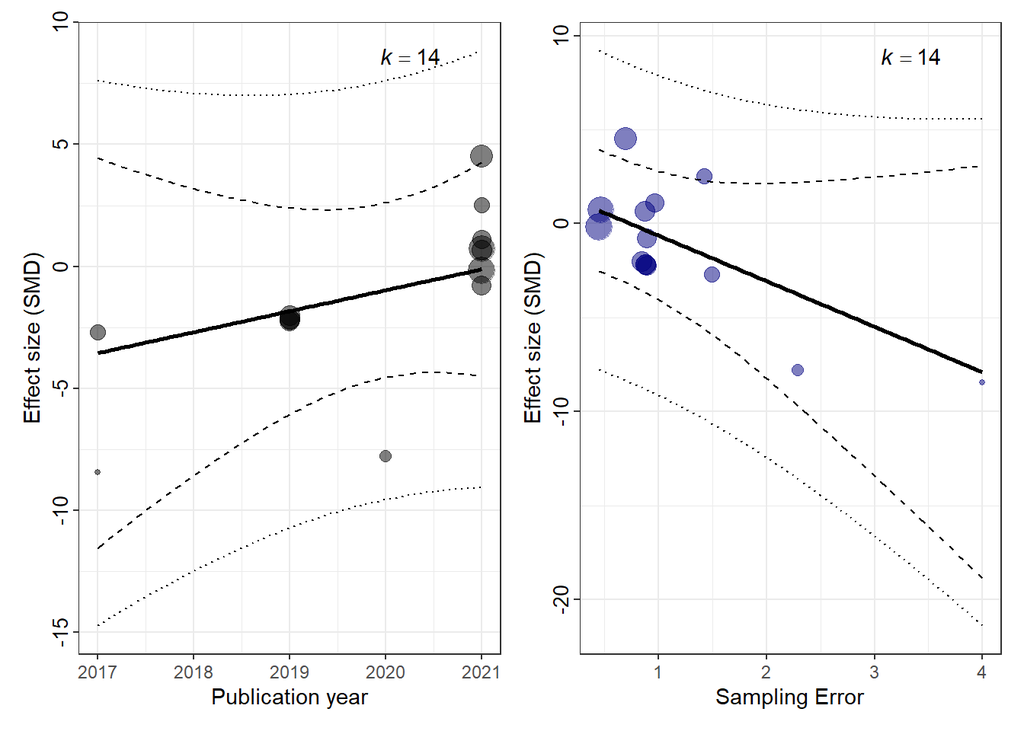

**Small-study effect** The regression slope of the extended Egger’s regression is $\sqrt{SMDSE} = -2.4236569$ is it statistically different from zero?`

If p<0.050: Smaller studies (with larger sampling error) have larger effect sizes –> small-study effect exists in this dataset. Data is assymmetrically distributed in the funnel plot.

If p>=0.050 no small-study effect exists in this dataset. Smaller studies (with larger sampling error) do not have larger effect sizes –> no small-study effect exists in this dataset. Data is symmetrically distributed in the funnel plot.

If p<0.050: studies with statistically significant findings tend to be published earlier than these with “negative” results, i.e. time-lag bias exists in this dataset

If p>=0.050: studies with statistically significant findings **do not** tend to be published earlier than these with “negative” results, i.e. no time-lag bias exists in this dataset

### Sensitivity analysis: publication bias with adapted SE

> Egger’s regression and its variants suffer from low power and poor performance when there are fewer than 20 effect sizes, or when the overall effect is large. (Nakagawa et al. 2022)

> Instead of the sample size (n1 + n2), however, for a meta-analysis of SMD or lnRR, we propose using the ‘effective sample size’ because it accounts for unbalanced sampling (cf. Stanley, 2005).(Nakagawa et al. 2022)

```r
if (mRE[[bias]]$pval[2] < 0.05) {

    # calculate modified SE based on effective sample size
    df$ess_vi <- with(df, sqrt((n_treat + n_ctrl)/(n_treat * n_ctrl)))
    df$ess_SE <- sqrt(df$ess_vi)  ## sampling error for ES

    # PET + year
    bias2 <- "PET sensitivity"
    mRE[[bias2]] <- rma.mv(yi, VCV, random = RE_formula, mods = ~ess_SE + pub_year,
        data = df, slab = Study, method = "REML", test = "t", dfs = "contain", level = 95)
    mRE[[bias2]] <- robust(mRE[[bias2]], cluster = df$Study, clubSandwich = TRUE)
    mRE[[bias2]] <- additional_results(mRE[[bias2]])

    # PEESE + year
    if (mRE[[bias2]]$pval[2] < 0.1) {
        mname <- "PEESE sensitivity"
        mRE[[mname]] <- rma.mv(yi, VCV, random = RE_formula, mods = ~ess_vi + pub_year,
            data = df, slab = Study, method = "REML", test = "t", dfs = "contain",
            level = 95)
        mRE[[mname]] <- robust(mRE[[mname]], cluster = df$Study, clubSandwich = TRUE)
        mRE[[mname]] <- additional_results(mRE[[mname]])
        bias2 <- mname
    }
    print(bias2)
    summary(mRE[[bias2]])
}
```

If the results are the same, indicates the robustness of the small-study test.

#### Plots

# Sensitivity

## Rho range

```r
if (VCVrho != 0) {

    rho_range <- c(0, 0.25, 0.75, 0.9)  # assume a range values of rho

    for (j in 1:length(rho_range)) {

        mname <- paste("rho", rho_range[j], sep = "_")

        VCV2 <- vcalc(vi, cluster = interaction(df$EScluster, df$Study), obs = ESid,
            data = df, rho = rho_range[j])

        mRE[[mname]] <- rma.mv(yi, VCV2, random = RE_formula, data = df, slab = Study,
            method = "REML", test = "t", dfs = "contain", level = 95)
        mRE[[mname]] <- robust(mRE[[mname]], cluster = df$Study, clubSandwich = TRUE)
        mRE[[mname]] <- additional_results(mRE[[mname]])
    }
}
```

## Leave one out + Rho range

```r
if (VCVrho != 0) {
    rho_range <- c(0.25, 0.5, 0.75, 0.9)
} else {
    rho_range <- 0
}

for (i in sort(unique(df$Study))) {

    df_temp <- df[df$Study != i, ]

    for (j in 1:length(rho_range)) {

        mname <- paste("rho", rho_range[j], "l1o", i, sep = "_")
        print(mname)
        VCV2 <- vcalc(vi, cluster = interaction(df_temp$EScluster, df_temp$Study),
            obs = ESid, data = df_temp, rho = rho_range[j])

        mRE[[mname]] <- rma.mv(yi, VCV2, random = RE_formula, data = df_temp, slab = Study,
            method = "REML", test = "t", dfs = "contain", level = 95)
        mRE[[mname]] <- robust(mRE[[mname]], cluster = df_temp$Study, clubSandwich = TRUE)
        mRE[[mname]] <- additional_results(mRE[[mname]])
    }
}
```

```
[1] "rho_0.25_l1o_Chagas et al., 2021"
[1] "rho_0.5_l1o_Chagas et al., 2021"
[1] "rho_0.75_l1o_Chagas et al., 2021"
[1] "rho_0.9_l1o_Chagas et al., 2021"
[1] "rho_0.25_l1o_Chen et al., 2017"
[1] "rho_0.5_l1o_Chen et al., 2017"
[1] "rho_0.75_l1o_Chen et al., 2017"
[1] "rho_0.9_l1o_Chen et al., 2017"
[1] "rho_0.25_l1o_Estrela et al., 2021"
[1] "rho_0.5_l1o_Estrela et al., 2021"
[1] "rho_0.75_l1o_Estrela et al., 2021"
[1] "rho_0.9_l1o_Estrela et al., 2021"
[1] "rho_0.25_l1o_Santos et al., 2020"
[1] "rho_0.5_l1o_Santos et al., 2020"
[1] "rho_0.75_l1o_Santos et al., 2020"
[1] "rho_0.9_l1o_Santos et al., 2020"
[1] "rho_0.25_l1o_Santos et al., 2021b"
[1] "rho_0.5_l1o_Santos et al., 2021b"
[1] "rho_0.75_l1o_Santos et al., 2021b"
[1] "rho_0.9_l1o_Santos et al., 2021b"
[1] "rho_0.25_l1o_Wan et al., 2019"
[1] "rho_0.5_l1o_Wan et al., 2019"
[1] "rho_0.75_l1o_Wan et al., 2019"
[1] "rho_0.9_l1o_Wan et al., 2019"
```

# Tables

|  | n studies | n ES clusters | n ES | overall effect | standard error | p-value | Lower CI | Upper CI | Lower PI | Upper PI | Q | Q p-value | $I^2$$_{total}$ | $I^2$$_{Study}$ | $I^2$$_{EScluster}$ | $I^2$$_{ES}$ | $\sigma^2$$_{Study}$ | $\sigma^2$$_{EScluster}$ | $\sigma^2$$_{ES}$ |
| --- | --- | --- | --- | --- | --- | --- | --- | --- | --- | --- | --- | --- | --- | --- | --- | --- | --- | --- | --- |
| ML | 6 | 9 | 14 | -0.80 | 1.5 | 0.6211 | -4.69 | 3.10 | -10.72 | 9.12 | 76.35 | 0 | 94.80 | 91.40 | 2.70 | 0.70 | 12.14 | 0.36 | 0.09 |
| ML_RobVar | 6 | 9 | 14 | -0.80 | 1.5 | 0.6203 | -4.70 | 3.10 | -10.76 | 9.16 | 76.35 | 0 | 94.80 | 91.40 | 2.70 | 0.70 | 12.14 | 0.36 | 0.09 |
| PET | 6 | 9 | 14 | 1.98 | 1.2 | 0.2006 | -1.96 | 5.91 | -6.77 | 10.73 | 52.26 | 0 | 88.91 | 51.67 | 35.58 | 1.66 | 3.22 | 2.22 | 0.10 |
| rho_0 | 6 | 9 | 14 | -0.99 | 1.6 | 0.5553 | -5.01 | 3.04 | -11.30 | 9.33 | 93.98 | 0 | 95.14 | 92.00 | 2.98 | 0.16 | 13.09 | 0.42 | 0.02 |
| rho_0.25 | 6 | 9 | 14 | -0.91 | 1.5 | 0.5822 | -4.88 | 3.07 | -11.07 | 9.26 | 81.60 | 0 | 95.00 | 91.74 | 2.81 | 0.44 | 12.67 | 0.39 | 0.06 |
| rho_0.75 | 6 | 9 | 14 | -0.63 | 1.5 | 0.6853 | -4.42 | 3.16 | -10.31 | 9.05 | 76.37 | 0 | 94.51 | 90.89 | 2.68 | 0.94 | 11.45 | 0.34 | 0.12 |
| rho_0.9 | 6 | 9 | 14 | -0.46 | 1.4 | 0.7586 | -4.16 | 3.23 | -9.95 | 9.03 | 87.18 | 0 | 94.31 | 90.51 | 2.77 | 1.03 | 11.00 | 0.34 | 0.13 |
| rho_0.25_l1o_Chagas et al., 2021 | 5 | 8 | 12 | -1.24 | 1.9 | 0.5577 | -6.63 | 4.15 | -14.00 | 11.53 | 78.86 | 0 | 94.40 | 91.98 | 2.42 | 0.00 | 16.79 | 0.44 | 0.00 |
| rho_0.5_l1o_Chagas et al., 2021 | 5 | 8 | 12 | -1.10 | 1.9 | 0.5938 | -6.41 | 4.21 | -13.67 | 11.46 | 71.96 | 0 | 94.22 | 91.72 | 2.51 | 0.00 | 16.23 | 0.44 | 0.00 |
| rho_0.75_l1o_Chagas et al., 2021 | 5 | 8 | 12 | -0.89 | 1.9 | 0.6578 | -6.06 | 4.29 | -13.17 | 11.40 | 67.38 | 0 | 93.98 | 91.35 | 2.64 | 0.00 | 15.52 | 0.45 | 0.00 |
| rho_0.9_l1o_Chagas et al., 2021 | 5 | 8 | 12 | -0.66 | 1.8 | 0.7333 | -5.73 | 4.40 | -12.78 | 11.45 | 65.32 | 0 | 93.84 | 91.11 | 2.73 | 0.00 | 15.12 | 0.45 | 0.00 |
| rho_0.25_l1o_Chen et al., 2017 | 5 | 8 | 12 | -0.56 | 1.8 | 0.7694 | -5.58 | 4.45 | -12.64 | 11.51 | 74.56 | 0 | 96.25 | 93.43 | 2.46 | 0.37 | 15.05 | 0.40 | 0.06 |
| rho_0.5_l1o_Chen et al., 2017 | 5 | 8 | 12 | -0.56 | 1.8 | 0.7707 | -5.58 | 4.46 | -12.65 | 11.52 | 70.08 | 0 | 96.26 | 93.44 | 2.26 | 0.56 | 15.06 | 0.36 | 0.09 |
| rho_0.75_l1o_Chen et al., 2017 | 5 | 8 | 12 | -0.56 | 1.8 | 0.7722 | -5.59 | 4.47 | -12.65 | 11.53 | 70.77 | 0 | 96.26 | 93.44 | 2.11 | 0.71 | 15.07 | 0.34 | 0.11 |
| rho_0.9_l1o_Chen et al., 2017 | 5 | 8 | 12 | -0.56 | 1.8 | 0.7734 | -5.59 | 4.48 | -12.65 | 11.54 | 81.97 | 0 | 96.26 | 93.44 | 2.07 | 0.75 | 15.07 | 0.33 | 0.12 |
| rho_0.25_l1o_Estrela et al., 2021 | 5 | 8 | 13 | -1.83 | 1.2 | 0.2169 | -5.33 | 1.67 | -9.91 | 6.25 | 39.10 | 0 | 90.18 | 85.22 | 4.13 | 0.82 | 6.25 | 0.30 | 0.06 |
| rho_0.5_l1o_Estrela et al., 2021 | 5 | 8 | 13 | -1.69 | 1.2 | 0.2343 | -5.09 | 1.71 | -9.50 | 6.12 | 36.08 | 0 | 89.50 | 84.20 | 3.95 | 1.36 | 5.78 | 0.27 | 0.09 |
| rho_0.75_l1o_Estrela et al., 2021 | 5 | 8 | 13 | -1.48 | 1.1 | 0.2666 | -4.70 | 1.74 | -8.90 | 5.95 | 37.53 | 0 | 88.50 | 82.61 | 3.99 | 1.90 | 5.17 | 0.25 | 0.12 |
| rho_0.9_l1o_Estrela et al., 2021 | 5 | 8 | 13 | -1.26 | 1.1 | 0.3137 | -4.36 | 1.83 | -8.49 | 5.97 | 48.76 | 0 | 88.04 | 81.64 | 4.28 | 2.11 | 4.91 | 0.26 | 0.13 |
| rho_0.25_l1o_Santos et al., 2020 | 5 | 8 | 13 | 0.16 | 1.3 | 0.9037 | -3.38 | 3.70 | -8.24 | 8.57 | 69.11 | 0 | 92.06 | 85.98 | 5.37 | 0.71 | 6.99 | 0.44 | 0.06 |
| rho_0.5_l1o_Santos et al., 2020 | 5 | 8 | 13 | 0.28 | 1.2 | 0.8296 | -3.12 | 3.67 | -7.74 | 8.30 | 63.35 | 0 | 91.32 | 84.54 | 5.57 | 1.22 | 6.29 | 0.41 | 0.09 |
| rho_0.75_l1o_Santos et al., 2020 | 5 | 8 | 13 | 0.44 | 1.1 | 0.7190 | -2.74 | 3.63 | -7.07 | 7.95 | 63.04 | 0 | 90.22 | 82.31 | 6.17 | 1.75 | 5.43 | 0.41 | 0.12 |
| rho_0.9_l1o_Santos et al., 2020 | 5 | 8 | 13 | 0.60 | 1.1 | 0.6087 | -2.39 | 3.59 | -6.48 | 7.68 | 73.77 | 0 | 89.18 | 80.09 | 7.04 | 2.05 | 4.78 | 0.42 | 0.12 |
| rho_0.25_l1o_Santos et al., 2021b | 5 | 5 | 10 | -1.32 | 1.9 | 0.5291 | -6.66 | 4.02 | -13.97 | 11.33 | 76.52 | 0 | 96.41 | 48.03 | 48.03 | 0.34 | 8.43 | 8.43 | 0.06 |
| rho_0.5_l1o_Santos et al., 2021b | 5 | 5 | 10 | -1.19 | 1.9 | 0.5621 | -6.46 | 4.08 | -13.66 | 11.27 | 71.66 | 0 | 96.30 | 47.88 | 47.88 | 0.55 | 8.16 | 8.16 | 0.09 |
| rho_0.75_l1o_Santos et al., 2021b | 5 | 5 | 10 | -0.99 | 1.8 | 0.6193 | -6.15 | 4.16 | -13.21 | 11.22 | 71.81 | 0 | 96.16 | 47.72 | 47.72 | 0.72 | 7.83 | 7.83 | 0.12 |
| rho_0.9_l1o_Santos et al., 2021b | 5 | 5 | 10 | -0.79 | 1.8 | 0.6841 | -5.85 | 4.26 | -12.86 | 11.27 | 82.64 | 0 | 96.08 | 47.65 | 47.65 | 0.78 | 7.66 | 7.66 | 0.13 |
| rho_0.25_l1o_Wan et al., 2019 | 5 | 8 | 10 | -0.73 | 1.9 | 0.7214 | -6.05 | 4.59 | -13.37 | 11.91 | 60.96 | 0 | 96.10 | 93.53 | 0.92 | 1.64 | 16.46 | 0.16 | 0.29 |
| rho_0.5_l1o_Wan et al., 2019 | 5 | 8 | 10 | -0.61 | 1.9 | 0.7601 | -5.82 | 4.60 | -12.98 | 11.76 | 60.64 | 0 | 95.93 | 93.24 | 0.56 | 2.13 | 15.72 | 0.09 | 0.36 |
| rho_0.75_l1o_Wan et al., 2019 | 5 | 8 | 10 | -0.44 | 1.8 | 0.8208 | -5.49 | 4.61 | -12.45 | 11.57 | 63.62 | 0 | 95.69 | 92.77 | 0.00 | 2.91 | 14.78 | 0.00 | 0.46 |
| rho_0.9_l1o_Wan et al., 2019 | 5 | 8 | 10 | -0.29 | 1.8 | 0.8792 | -5.20 | 4.63 | -12.02 | 11.45 | 75.91 | 0 | 95.50 | 91.81 | 0.00 | 3.69 | 14.01 | 0.00 | 0.56 |

|  | ML | ML_RobVar | PET | rho_0 | rho_0.25 | rho_0.75 | rho_0.9 | rho_0.25_l1o_Chagas.et.al...2021 | rho_0.5_l1o_Chagas.et.al...2021 | rho_0.75_l1o_Chagas.et.al...2021 | rho_0.9_l1o_Chagas.et.al...2021 | rho_0.25_l1o_Chen.et.al...2017 | rho_0.5_l1o_Chen.et.al...2017 | rho_0.75_l1o_Chen.et.al...2017 | rho_0.9_l1o_Chen.et.al...2017 | rho_0.25_l1o_Estrela.et.al...2021 | rho_0.5_l1o_Estrela.et.al...2021 | rho_0.75_l1o_Estrela.et.al...2021 | rho_0.9_l1o_Estrela.et.al...2021 | rho_0.25_l1o_Santos.et.al...2020 | rho_0.5_l1o_Santos.et.al...2020 | rho_0.75_l1o_Santos.et.al...2020 | rho_0.9_l1o_Santos.et.al...2020 | rho_0.25_l1o_Santos.et.al...2021b | rho_0.5_l1o_Santos.et.al...2021b | rho_0.75_l1o_Santos.et.al...2021b | rho_0.9_l1o_Santos.et.al...2021b | rho_0.25_l1o_Wan.et.al...2019 | rho_0.5_l1o_Wan.et.al...2019 | … |
| --- | --- | --- | --- | --- | --- | --- | --- | --- | --- | --- | --- | --- | --- | --- | --- | --- | --- | --- | --- | --- | --- | --- | --- | --- | --- | --- | --- | --- | --- | --- |
| logLik: | -26.61851976532946 | -26.61851976532946 | -19.67411391642537 | -27.17550404984118 | -26.91560227577961 | -26.27539340040284 | -26.0411022084428 | -22.92576242705263 | -22.44050382086919 | -21.68458512386355 | -20.74246287113766 | -21.07529199330284 | -20.70478363898208 | -20.17872218029562 | -19.69663122654769 | -23.08762505252673 | -22.80158148242428 | -22.49256230355564 | -22.33254691573201 | -22.79390578449816 | -22.37824671584909 | -21.85060516221344 | -21.43608333854295 | -18.91072766355764 | -18.64120330938729 | -18.33809281445049 | -18.13562384230538 | -21.69568364914194 | -21.76468181761457 | … |
| deviance: | 53.23703953065892 | 53.23703953065892 | 39.34822783285074 | 54.35100809968236 | 53.83120455155921 | 52.55078680080567 | 52.0822044168856 | 45.85152485410525 | 44.88100764173838 | 43.36917024772711 | 41.48492574227533 | 42.15058398660567 | 41.40956727796416 | 40.35744436059124 | 39.39326245309539 | 46.17525010505346 | 45.60316296484856 | 44.98512460711128 | 44.66509383146402 | 45.58781156899633 | 44.75649343169819 | 43.70121032442687 | 42.8721666770859 | 37.82145532711528 | 37.28240661877459 | 36.67618562890098 | 36.27124768461076 | 43.39136729828389 | 43.52936363522914 | … |
| AIC: | 61.23703953065892 | 61.23703953065892 | 51.34822783285074 | 62.35100809968236 | 61.83120455155921 | 60.55078680080567 | 60.0822044168856 | 53.85152485410525 | 52.88100764173838 | 51.36917024772711 | 49.48492574227533 | 50.15058398660567 | 49.40956727796416 | 48.35744436059124 | 47.39326245309539 | 54.17525010505346 | 53.60316296484856 | 52.98512460711128 | 52.66509383146402 | 53.58781156899633 | 52.75649343169819 | 51.70121032442687 | 50.8721666770859 | 45.82145532711528 | 45.28240661877459 | 44.67618562890098 | 44.27124768461076 | 51.39136729828389 | 51.52936363522914 | … |
| BIC: | 63.49683696050506 | 63.49683696050506 | 53.73559946964096 | 64.6108055295285 | 64.09100198140536 | 62.81058423065182 | 62.34200184673174 | 55.44310594529873 | 54.47258873293186 | 52.96075133892059 | 51.07650683346881 | 51.74216507779916 | 51.00114836915765 | 49.94902545178472 | 48.98484354428887 | 56.11487670420546 | 55.54278956400056 | 54.92475120626328 | 54.60472043061602 | 55.52743816814833 | 54.69612003085019 | 53.64083692357887 | 52.8117932762379 | 46.61035363646016 | 46.07130492811947 | 45.46508393824586 | 45.06014599395564 | 52.18026560762877 | 52.31826194457402 | … |
| AICc: | 66.23703953065892 | 66.23703953065892 | 72.34822783285074 | 67.35100809968236 | 66.83120455155921 | 65.55078680080567 | 65.08220441688559 | 60.51819152077191 | 59.54767430840504 | 58.03583691439377 | 56.15159240894199 | 56.81725065327234 | 56.07623394463083 | 55.0241110272579 | 54.05992911976205 | 59.88953581933918 | 59.31744867913428 | 58.699410321397 | 58.37937954574974 | 59.30209728328204 | 58.4707791459839 | 57.41549603871259 | 56.58645239137162 | 55.82145532711528 | 55.28240661877459 | 54.67618562890098 | 54.27124768461076 | 61.39136729828389 | 61.52936363522914 | … |

# Influential cases

> Outliers and influential cases can actually reveal patterns that may lead to new insights about study characteristics that could be acting as potential moderators (Viechtbauer and Cheung 2010)

Cook’s distance: examine what effect the deletion of the ith study has on the fitted values of all k studies simultaneously (Viechtbauer and Cheung 2010)

DFBETAS: directly examine the influence of deleting the ith case on each individual parameter estimate (Viechtbauer and Cheung 2010)

So if a point has high Cook’s Distance, use DFBETAS to identify witch estimate is mainly influenced (only makes sense for meta regression).

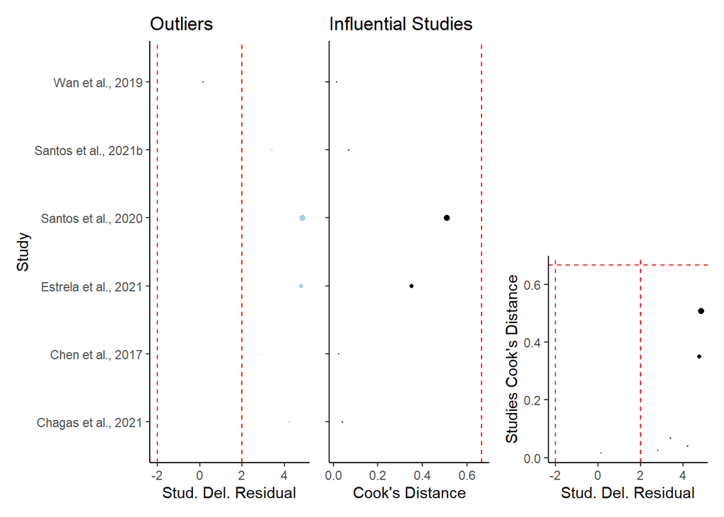

```r
influentialcases_plots(mRE, "ML_RobVar", "ML", 3)
```

# Multilevel meta-regression

SYRCLE PROTOCOL: Meta-regression will be used for outcomes with at least 10 experiments.

> The minimal number of studies or effect sizes required by a multilevel meta-regression remains unknown, albeit some simulation studies suggest that the estimates of model coefficients of a multilevel meta-regression are generally stable under various simulated situations.(Yang et al. 2023) … the complexity of parameterization of such a meta-regression requires a large dataset to make optimization algorithms free of convergence issues.(Yang et al. 2023)

## Model 1: Size, Duration, Development

```r
df_MR <- select(df, c("Year", "StudyID", "Study", "EScluster", "ESid", "DevelopmentalStage",
    "ExposureDurationDays", "ParticleSizeMean", "yi", "vi"))

mname1 <- "Base"
mname2 <- paste0(mname1, "_RobVar")

mods_formula <- formula(~ParticleSizeMean + ExposureDurationDays * DevelopmentalStage)

mMR[[mname1]] <- rma.mv(yi, VCV, random = RE_formula, mods = mods_formula, data = df_MR,
    slab = Study, method = "REML", test = "t", dfs = "contain", level = 95)  #it will only keep complete cases

nSt_MR <- mMR[[mname1]]$s.nlevels[1]  # number of studies
nEC_MR <- mMR[[mname1]]$s.nlevels[2]  # number of ESclusters
nES_MR <- mMR[[mname1]]$s.nlevels[3]  # number of independent ES

print(paste0("Number of studies: ", nSt_MR, ", number of ES clusters: ", nEC_MR,
    " and number of independent observations of ES: ", nES_MR))
```

```
[1] "Number of studies: 6, number of ES clusters: 9 and number of independent observations of ES: 14"
```

```r
mMR[[mname2]] <- robust(mMR[[mname1]], cluster = df_MR$Study, clubSandwich = TRUE,
    verbose = TRUE)
mMR[[mname2]] <- additional_results(mMR[[mname2]])
```

The meta-regression comprised 14 comparisons from 9 control group clusters of 6 independent studies.

#### Diagnostics plots

```
Multivariate Meta-Analysis Model (k = 14; method: REML)

  logLik  Deviance       AIC       BIC      AICc
-17.7513   35.5027   51.5027   53.0805  195.5027

Variance Components:

            estim    sqrt  nlvls  fixed                factor
sigma^2.1  6.9946  2.6447      6     no                 Study
sigma^2.2  1.1046  1.0510      9     no       Study/EScluster
sigma^2.3  0.1323  0.3637     14     no  Study/EScluster/ESid

Test for Residual Heterogeneity:
QE(df = 9) = 31.4761, p-val = 0.0002

Number of estimates:   14
Number of clusters:    6
Estimates per cluster: 0-4 (mean: 0.24, median: 0)

Test of Moderators (coefficients 2:5):¹
F(df1 = 4, df2 = 0.13) = 0.8633, p-val = 0.8562

Model Results:

                            estimate      se¹     tval¹    df¹    pval¹
intrcpt                      -2.4147  3.4675   -0.6964   0.93   0.6200
ParticleSizeMean              0.0023  0.0189    0.1210   1.03   0.9229
ExposureDurationDays          0.0891  0.1099    0.8106   1.02   0.5642
DevelopmentalStageLarva      -0.4881  1.7835   -0.2737   0.92   0.8329
DevelopmentalStageJuvenile    6.6697  3.1548    2.1141   0.89   0.3038
                               ci.lb¹    ci.ub¹
intrcpt                     -55.5435   50.7141
ParticleSizeMean             -0.2223    0.2269
ExposureDurationDays         -1.2441    1.4223
DevelopmentalStageLarva     -28.3772   27.4010
DevelopmentalStageJuvenile  -46.5681   59.9075

---
Signif. codes:  0 '***' 0.001 '**' 0.01 '*' 0.05 '.' 0.1 ' ' 1

1) results based on cluster-robust inference (var-cov estimator: CR2,
   approx t/F-tests and confidence intervals, df: Satterthwaite approx)
```

|  | ML | REML |
| --- | --- | --- |
| ll | -27.05612 | -17.75133 |
| dev | 29.64072 | 35.50265 |
| AIC | 70.11223 | 51.50265 |
| BIC | 75.22469 | 53.08045 |
| AICc | 98.91223 | 195.50265 |

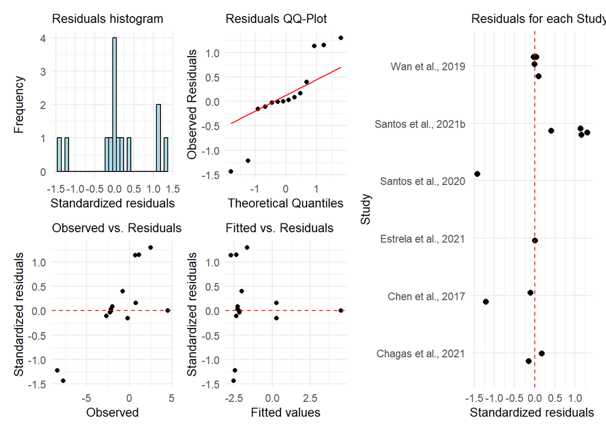

#### Influential cases

```
 Chagas et al., 2021    Chen et al., 2017 Estrela et al., 2021
                  NA            0.4502517                   NA
 Santos et al., 2020 Santos et al., 2021b     Wan et al., 2019
           1.9815571          639.9018262           28.1104865
```

[figure not shown]

#### Orchard plots

(Nakagawa et al. 2021)

## Model 2: + Concentration

```
[1] "Number of studies: 6, number of ES clusters: 9 and number of independent observations of ES: 14"
```

The meta-regression comprised 14 comparisons from 9 control group clusters of 6 independent studies.

#### Diagnostics plots

```
Multivariate Meta-Analysis Model (k = 14; method: REML)

  logLik  Deviance       AIC       BIC      AICc
-16.1824   32.3649   50.3649   51.0799  230.3649

Variance Components:

            estim    sqrt  nlvls  fixed                factor
sigma^2.1  7.3421  2.7096      6     no                 Study
sigma^2.2  1.2071  1.0987      9     no       Study/EScluster
sigma^2.3  0.0000  0.0000     14     no  Study/EScluster/ESid

Test for Residual Heterogeneity:
QE(df = 8) = 30.2006, p-val = 0.0002

Number of estimates:   14
Number of clusters:    6
Estimates per cluster: 0-4 (mean: 0.24, median: 0)

Test of Moderators (coefficients 2:6):¹
F(df1 = 5, df2 = 0) = 0.0000, p-val = NA

Model Results:

                            estimate      se¹     tval¹    df¹    pval¹
intrcpt                      -1.0290  3.0774   -0.3344   1.45   0.7799
ParticleSizeMean              0.0008  0.0163    0.0475   1.02   0.9697
Concentration_mg_L           -0.3412  0.0797   -4.2825   1.02   0.1432
ExposureDurationDays          0.0861  0.0900    0.9567   1.02   0.5117
DevelopmentalStageLarva      -1.3604  1.7179   -0.7919   1.55   0.5316
DevelopmentalStageJuvenile    5.5523  2.8238    1.9663   1.51   0.2280
                               ci.lb¹    ci.ub¹
intrcpt                     -20.3852   18.3272
ParticleSizeMean             -0.1957    0.1972
Concentration_mg_L           -1.3186    0.6362
ExposureDurationDays         -1.0081    1.1803
DevelopmentalStageLarva     -11.2661    8.5453
DevelopmentalStageJuvenile  -11.3201   22.4248

---
Signif. codes:  0 '***' 0.001 '**' 0.01 '*' 0.05 '.' 0.1 ' ' 1

1) results based on cluster-robust inference (var-cov estimator: CR2,
   approx t/F-tests and confidence intervals, df: Satterthwaite approx)
```

|  | ML | REML |
| --- | --- | --- |
| ll | -25.57482 | -16.18245 |
| dev | 26.67813 | 32.36490 |
| AIC | 69.14965 | 50.36490 |
| BIC | 74.90117 | 51.07987 |
| AICc | 114.14965 | 230.36490 |

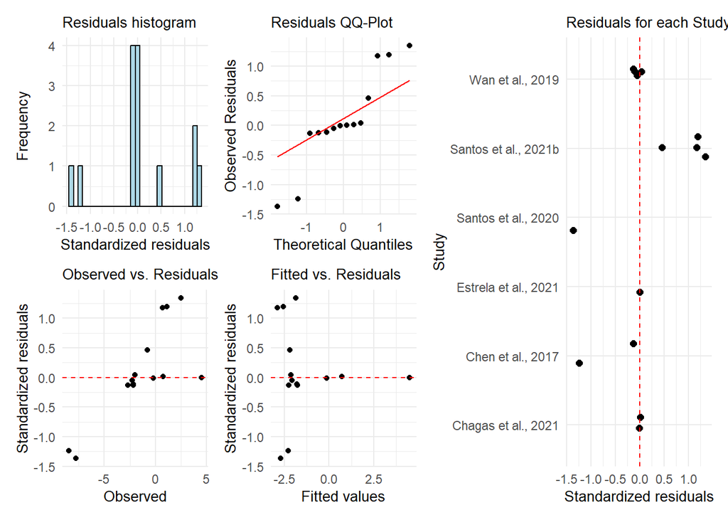

#### Influential cases

```
 Chagas et al., 2021    Chen et al., 2017 Estrela et al., 2021
                  NA             1.314523                   NA
 Santos et al., 2020 Santos et al., 2021b     Wan et al., 2019
            3.356799          1001.303856           358.459449
```

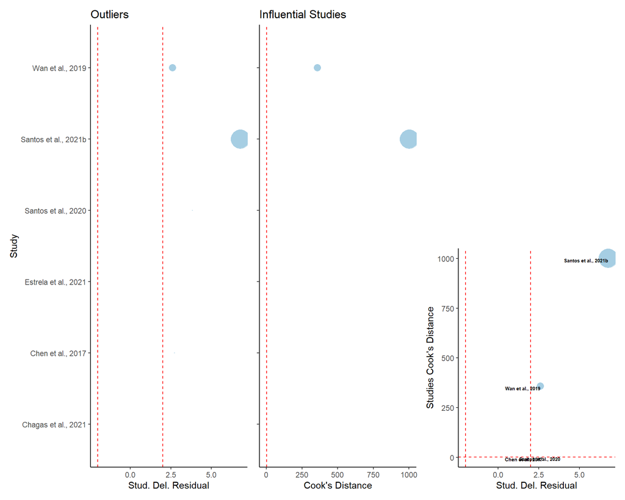

#### Orchard plots

## Model 3: + ParticleMaterial

```
[1] "Number of studies: 6, number of ES clusters: 9 and number of independent observations of ES: 14"
```

The meta-regression comprised 14 comparisons from 9 control group clusters of 6 independent studies.

#### Diagnostics plots

```
Multivariate Meta-Analysis Model (k = 14; method: REML)

  logLik  Deviance       AIC       BIC      AICc
-15.2676   30.5353   48.5353   49.2502  228.5353

Variance Components:

             estim    sqrt  nlvls  fixed                factor
sigma^2.1  13.1244  3.6228      6     no                 Study
sigma^2.2   1.1228  1.0596      9     no       Study/EScluster
sigma^2.3   0.1328  0.3644     14     no  Study/EScluster/ESid

Test for Residual Heterogeneity:
QE(df = 8) = 23.8665, p-val = 0.0024

Number of estimates:   14
Number of clusters:    6
Estimates per cluster: 0-4 (mean: 0.24, median: 0)

Test of Moderators (coefficients 2:6):¹
F(df1 = 5, df2 = 0) = 0.0000, p-val = NA

Model Results:

                            estimate      se¹     tval¹    df¹    pval¹
intrcpt                      -1.9791  2.3813   -0.8311   1.14   0.5443
ParticleSizeMean              0.0023  0.0253    0.0903   1.01   0.9425
ExposureDurationDays          0.0746  0.0528    1.4131   1.01   0.3899
DevelopmentalStageLarva      -1.2679  5.1590   -0.2458   1.28   0.8393
DevelopmentalStageJuvenile    5.8401  5.3856    1.0844   1.32   0.4376
ParticleMaterialPS            0.4376  4.2481    0.1030      2   0.9273
                               ci.lb¹    ci.ub¹
intrcpt                     -24.7440   20.7857
ParticleSizeMean             -0.3127    0.3173
ExposureDurationDays         -0.5763    0.7255
DevelopmentalStageLarva     -40.8640   38.3281
DevelopmentalStageJuvenile  -33.6929   45.3731
ParticleMaterialPS          -17.8048   18.6799

---
Signif. codes:  0 '***' 0.001 '**' 0.01 '*' 0.05 '.' 0.1 ' ' 1

1) results based on cluster-robust inference (var-cov estimator: CR2,
   approx t/F-tests and confidence intervals, df: Satterthwaite approx)
```

|  | ML | REML |
| --- | --- | --- |
| ll | -27.99611 | -15.26764 |
| dev | 31.52070 | 30.53527 |
| AIC | 73.99221 | 48.53527 |
| BIC | 79.74373 | 49.25025 |
| AICc | 118.99221 | 228.53527 |

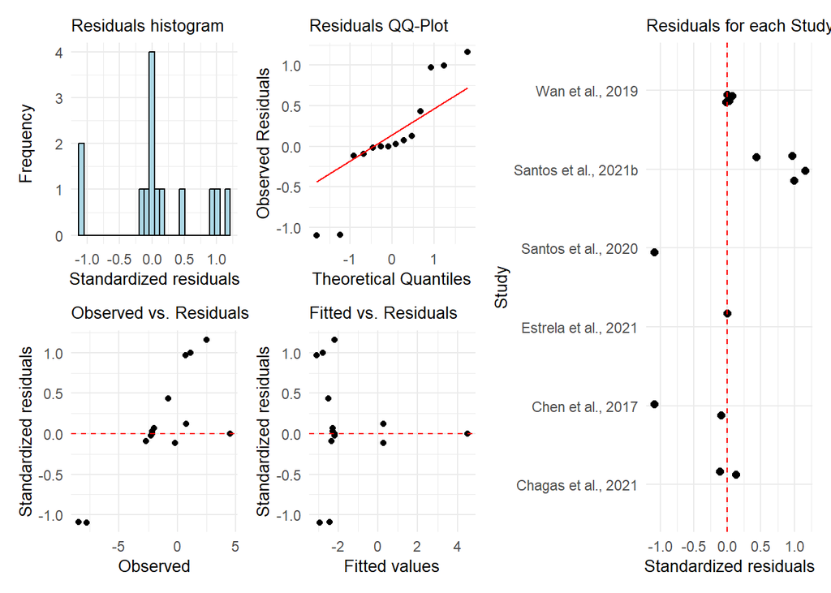

#### Influential cases

```
 Chagas et al., 2021    Chen et al., 2017 Estrela et al., 2021
                  NA           0.09987611                   NA
 Santos et al., 2020 Santos et al., 2021b     Wan et al., 2019
          2.35009181           7.84776127          29.17754568
```

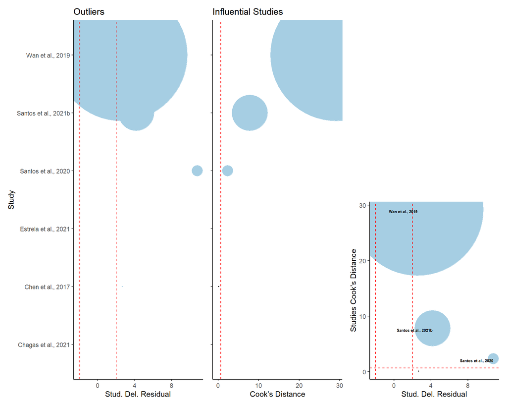

#### Orchard plots

# Referências

Harrer, Mathias, Pim Cuijpers, Toshi A. Furukawa, and David D. Ebert. n.d. *Chapter 9 Publication Bias | Doing Meta-Analysis in R*. https://bookdown.org/MathiasHarrer/Doing_Meta_Analysis_in_R/pub-bias.html.

Nakagawa, Shinichi, Malgorzata Lagisz, Michael D. Jennions, Julia Koricheva, Daniel W. A. Noble, Timothy H. Parker, Alfredo Sánchez-Tójar, Yefeng Yang, and Rose E. O’Dea. 2022. “Methods for Testing Publication Bias in Ecological and Evolutionary Meta-Analyses.” *Methods in Ecology and Evolution* 13 (1): 4–21. https://doi.org/10.1111/2041-210X.13724.

Nakagawa, Shinichi, Malgorzata Lagisz, Rose E. O’Dea, Joanna Rutkowska, Yefeng Yang, Daniel W. A. Noble, and Alistair M. Senior. 2021. “The Orchard Plot: Cultivating a Forest Plot for Use in Ecology, Evolution, and Beyond.” *Research Synthesis Methods* 12 (1): 4–12. https://doi.org/10.1002/jrsm.1424.

Stanley, T. D. 2017. “Limitations of PET-PEESE and Other Meta-Analysis Methods.” *Social Psychological and Personality Science* 8 (5): 581–91. https://doi.org/10.1177/1948550617693062.

Viechtbauer, Wolfgang. 2010. “Conducting Meta-Analyses in R with the Metafor Package.” *Journal of Statistical Software* 36 (August): 1–48. https://doi.org/10.18637/jss.v036.i03.

———. 2022. “Konstantopoulos (2011) [the Metafor Package].” https://www.metafor-project.org/doku.php/analyses:konstantopoulos2011.

Viechtbauer, Wolfgang, and Mike W.-L. Cheung. 2010. “Outlier and Influence Diagnostics for Meta-Analysis.” *Research Synthesis Methods* 1 (2): 112–25. https://doi.org/10.1002/jrsm.11.

Yang, Yefeng, Malcolm Macleod, Jinming Pan, Malgorzata Lagisz, and Shinichi Nakagawa. 2023. “Advanced Methods and Implementations for the Meta-Analyses of Animal Models: Current Practices and Future Recommendations.” *Neuroscience & Biobehavioral Reviews* 146 (March): 105016. https://doi.org/10.1016/j.neubiorev.2022.105016.